# Evaluation Metrics for Blocking/Entity Resolution

STA 325: Homework 2

Noah Obuya | 1234887 | 09/10/2024

*General instructions for homeworks*: Your code must be completely reproducible and must compile. No late homeworks will be accepted.

*Reading* Read the paper Binette and Steorts (2022) to get an overview of entity resolution. You’ll want to refer to this during the course of the semester as it’s meant to be a quick reference regarding the concepts that we will be covering. For more details, refer to the book by Christen (2012).

*Advice*: Start early on the homeworks and it is advised that you not wait until the day of as these homeworks are meant to be longer and treated as case studies.

*Commenting code* Code should be commented. See the Google style guide for questions regarding commenting or how to write code .

*R Markdown Test*

0. Open a new R Markdown file; set the output to HTML mode and “Knit”. This should produce a web page with the knitting procedure executing your code blocks. You can edit this new file to produce your homework submission.
1. (4 points) What are the four main challenges of entity resolution?

```r
library(tidyverse)
```

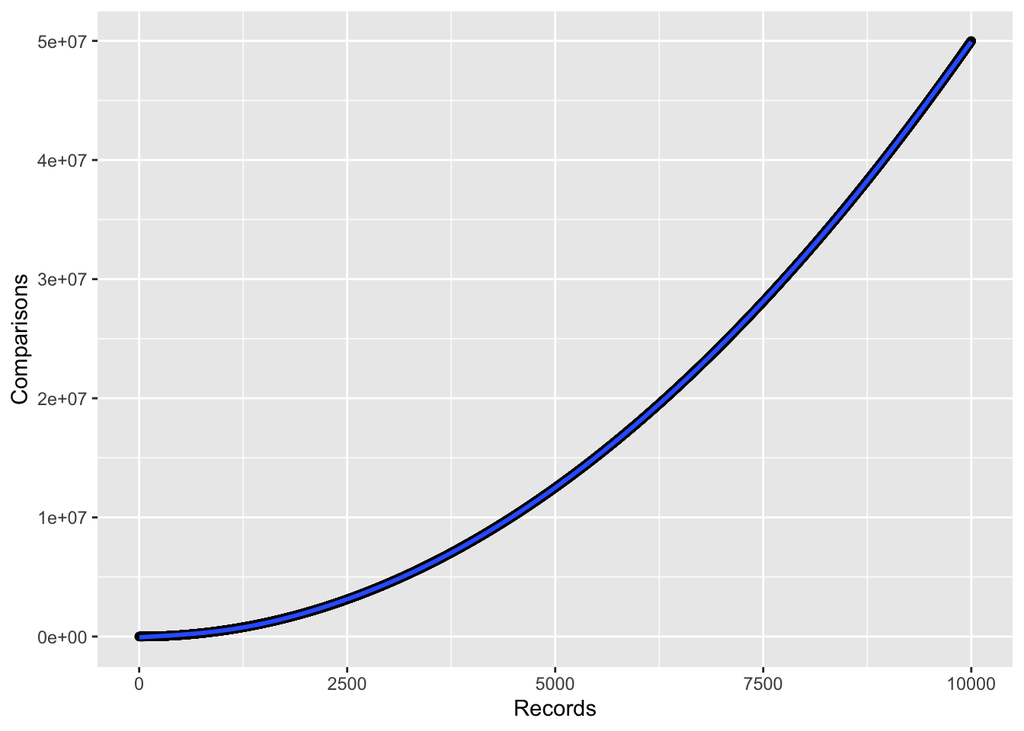

```r
        #create table to base graph on
        comparison_table <- data.frame(
          Records = 1:10000,
          Comparisons = sapply(1:10000, function(n) (n * (n - 1)) / 2)
        )
        #create graph using ggplot
        comparison_table |>
          ggplot(aes(x = Records, y = Comparisons)) +
          geom_point() +
          geom_smooth(se = FALSE)
```

What do you observe about the number of comparisons that need to be made?

3. (9 points) Consider the following record linkage data set with 1,000,000 total records that are matched between two databases. Assume that 500,000 are true matches. Assume a classified (or method) finds 600,000 record pairs as matches, and of these 400,000 correspond as true matches. The number of TP + FP + TN + FN = 50,000,000.
1. (4 points) Given the information above, find the following information in the confusion matrix: TP, FP, TN, and FN.

   False positives = Total predicted matches - true positives = 600000 - 400000 = 200000

   False negatives = Actual positives - true positives = 500000 - 400000 = 100000

   TP/ TP + FP = 4/6 = 0.667 (66.7%)
4. (1 point) Calculate the recall.

   TP/ (TP + FN) = 4/5 (80%)
5. (1 point) Calculate the f-measure.

   Precision*Recall / (Precision + Recall) = 0.667 * 0.8/ (0.8 + 0.667) = 0.727
6. (1 point) Comment on the reliability of the precision, recall, and f-measure for this problem.

   Precision of 66.67% shows that a fair number of predicted matches are false positives, meaning that the classifier is not entirely accurate in predicting true matches. Recall of 80% indicates that the classifier is good at capturing most of the actual matches but still misses some true matches. F-Measure balances precision and recall, giving an overall view of classifier performance. A value of 72.7% shows that the classifier performs moderately well, but improvements could be made, especially in reducing false positives.
4. (6 points) We will revisit the Italian Survey on Household and Wealth (SHIW) from class, which is a sample survey 383 households conducted by the Bank of Italy every two years (2008 and 2010). The data set is anonymized to remove first and last name (and other sensitive information).
1. (0 points) Please load the data set in the way that we did in class and block based upon gender.
2. (1 point) Plot the size of the blocks and comment on how many their are and their relative size.
3. (1 point) Calculate the reduction ratio and interpret its meaning.
4. (2 points) Calculate the precision and recall. Interpret the meaning of each.
5. (1 point) Would this be a reasonable approach for blocking. Explain.

   A high reduction ratio would suggest that the blocking ratio is appropriate.
6. (1 point) Would blocking on gender be recommended for entity resolution. Explain.

   Blocking based on gender is not recommended for entity resolution. It creates potential for missing true matches and a reduction of false matches.

```r
#given code start
library(italy)
library(assert)
data(italy08)
data(italy10)
knitr::opts_chunk$set(echo = TRUE,
                      fig.width=4,
                      fig.height=3,
                      fig.align="center")
head(italy08)
```

|  | id | PARENT | SEX | ANASC | NASCREG | CIT | ACOM4C | STUDIO | Q | QUAL | SETT | IREG |
| --- | --- | --- | --- | --- | --- | --- | --- | --- | --- | --- | --- | --- |
| 1 | 1040021 | 1 | 2 | 1948 | 16 | 1 | 0 | 5 | 1 | 2 | 3 | 16 |
| 2 | 1040022 | 10 | 2 | 1952 | 16 | 1 | 0 | 7 | 1 | 2 | 3 | 16 |
| 3 | 1110521 | 1 | 1 | 1972 | 20 | 1 | 2 | 5 | 1 | 1 | 4 | 20 |
| 4 | 1110522 | 3 | 1 | 1935 | 20 | 1 | 2 | 2 | 3 | 6 | 5 | 20 |
| 5 | 1110523 | 3 | 2 | 1941 | 20 | 1 | 2 | 3 | 3 | 6 | 5 | 20 |
| 6 | 119401 | 1 | 1 | 1941 | 7 | 1 | 0 | 4 | 3 | 6 | 5 | 7 |

```r
head(italy10)
```

|  | id | PARENT | SEX | ANASC | NASCREG | CIT | ACOM4C | STUDIO | Q | QUAL | SETT | IREG |
| --- | --- | --- | --- | --- | --- | --- | --- | --- | --- | --- | --- | --- |
| 1 | 1040021 | 1 | 2 | 1948 | 16 | 1 | 0 | 5 | 3 | 6 | 5 | 16 |
| 2 | 1040022 | 11 | 2 | 1952 | 16 | 1 | 0 | 7 | 1 | 2 | 3 | 16 |
| 3 | 1110521 | 1 | 2 | 1941 | 20 | 1 | 2 | 3 | 3 | 6 | 5 | 20 |
| 4 | 1110522 | 2 | 1 | 1935 | 20 | 1 | 2 | 2 | 3 | 6 | 5 | 20 |
| 5 | 1110523 | 6 | 1 | 1972 | 20 | 1 | 2 | 5 | 1 | 1 | 4 | 20 |
| 6 | 119721 | 1 | 2 | 1948 | 16 | 1 | 2 | 2 | 2 | 5 | 4 | 17 |

```r
id08 <- italy08$id
id10 <- italy10$id
id <- c(italy08$id, italy10$id) # combine the id
italy08 <- italy08[-c(1)] # remove the id
italy10 <- italy10[-c(1)] # remove the id
italy <- rbind(italy08, italy10)
head(italy)
```

|  | PARENT | SEX | ANASC | NASCREG | CIT | ACOM4C | STUDIO | Q | QUAL | SETT | IREG |
| --- | --- | --- | --- | --- | --- | --- | --- | --- | --- | --- | --- |
| 1 | 1 | 2 | 1948 | 16 | 1 | 0 | 5 | 1 | 2 | 3 | 16 |
| 2 | 10 | 2 | 1952 | 16 | 1 | 0 | 7 | 1 | 2 | 3 | 16 |
| 3 | 1 | 1 | 1972 | 20 | 1 | 2 | 5 | 1 | 1 | 4 | 20 |
| 4 | 3 | 1 | 1935 | 20 | 1 | 2 | 2 | 3 | 6 | 5 | 20 |
| 5 | 3 | 2 | 1941 | 20 | 1 | 2 | 3 | 3 | 6 | 5 | 20 |
| 6 | 1 | 1 | 1941 | 7 | 1 | 0 | 4 | 3 | 6 | 5 | 7 |

```r
#given code end

library(italy)
library(dplyr)

# Load required libraries
library(RecordLinkage)
library(data.table)
```

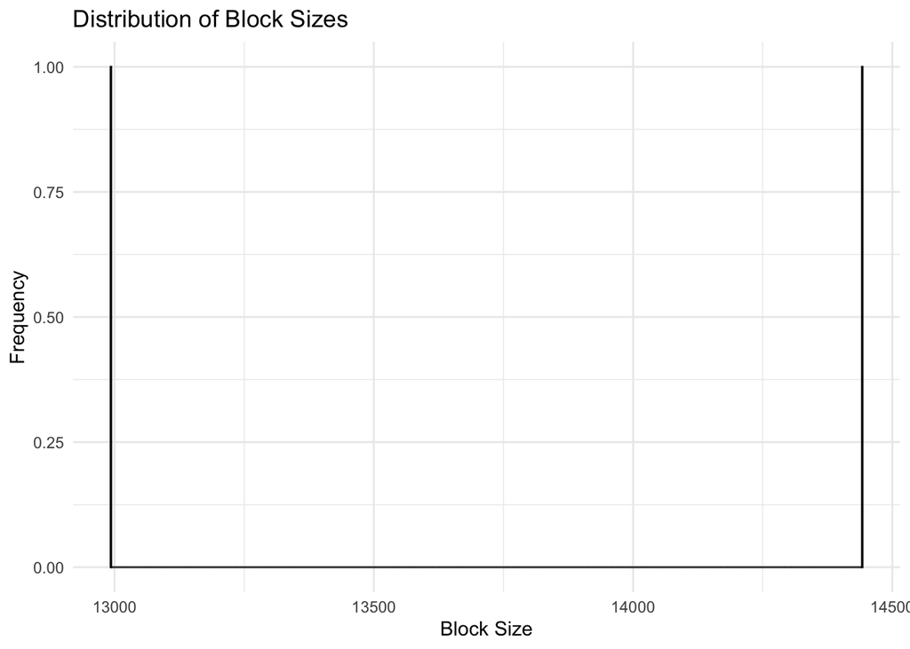

```r
library(ggplot2)

# Example data preparation
data08 <- as.data.table(italy08)
data10 <- as.data.table(italy10)
combined_data <- rbind(data08, data10)

# Create a blocking attribute (e.g., 'gender')
combined_data[, block := SEX]

# Ensure 'block' exists and has no missing values
combined_data <- combined_data[!is.na(block)]



# Count block sizes
block_sizes <- combined_data[, .(block_size = .N), by = block]

# Plot distribution of block sizes
ggplot(block_sizes, aes(x = block_size)) +
  geom_histogram(binwidth = 1, fill = "skyblue", color = "black") +
  labs(title = "Distribution of Block Sizes", x = "Block Size", y = "Frequency") +
  theme_minimal()
```

```r
# Calculate total possible comparisons without blocking
n_total <- nrow(combined_data)
total_comparisons_no_block <- choose(n_total, 2)

# Calculate total comparisons within blocks
total_comparisons_with_block <- block_sizes[, sum(choose(block_size, 2))]

# Calculate reduction ratio
reduction_ratio <- 1 - (total_comparisons_with_block / total_comparisons_no_block)
print(paste("Reduction Ratio:", reduction_ratio))
```

```
## [1] "Reduction Ratio: 0.498623423190158"
```